# Non-parametric Density Estimation

**Submitted by: Pankaj Chauhan ; Sudhanshu Gupta**

# Introduction

It is useful to know the probability density function for a sample of data to know whether a given observation is unlikely, or so unlikely as to be considered an outlier or anomaly and whether it should be removed. So far, we’ve assumed that the forms of the underlying densities were of some particular known parametric form.

But in cases where the Parametric form of the density is not known, **Density Estimation** is what we do for the observations in a random sample to estimate the general density of probabilities beyond just the sample of data available.

*A density estimator is an algorithm that seeks to model the probability distribution that generated a dataset.*

We will see some nonparametric procedures that can be used with arbitrary distributions without the assumption that the underlying form of the densities is known.

1. **Histograms**
2. **Kernel Density Estimation**

# Histogram as a Density Representation

The simplest method to estimate a density $f$ from an iid sample $X_{1},\ldots,X_{n}$ is the histogram. From an analytical point of view, the idea is to aggregate the data in intervals of the form $[x_0,x_0+h)$ and then use their relative frequency to approximate the density at $x\in[x_0,x_0+h),f(x)$ by the estimate of:

\begin{align*} f(x_0)&=F'(x_0)\\ &=\lim_{h\to0^+}\frac{F(x_0+h)-F(x_0)}{h}\\ &=\lim_{h\to0^+}\frac{\mathbb{P}[x_0<X< x_0+h]}{h}. \end{align*}

More precisely, given an origin $x_{0}$ and a *bandwidth* the histogram builds a piecewise constant function in the intervals $[x_{0}+mh,x_{0}+(m+1)h),m\in\mathbb{Z}$ by counting the number of sample points inside each of them. These constant-length intervals are also called *bins*.

If we denote the number of observations $X_{1},\ldots,X_{n}$ in a interval $n_{j}$, then the histogram can be written as

$$ \hat f(x)=\frac {n_j}{nh} $$

where $n_j$ is the number of observations in jth bin.

A histogram is used to summarize the distribution of observed values. It is the most frequently used univariate density estimator because of the easiness of implementation and interpretation.

Clearly, the shape of the histogram depends on:

- **Bandwidth**($h$) , which controls the bin size and the effective number of bins for aggregating the sample.
- **Origin**($x_{0}$), since the separation between bins happens at $(x_{0}+(m+1)h)$ , $m\in\mathbb{Z}$

## Histogram Density as a Function of Bin Width

A histogram is the simplest non-parametric density estimator. But at the same time is a highly subjective structure as its shape depends on the subjective choice of the number (or widths) of class intervals (bins) to which the range of a sample is divided, and on the choice of the initial point. The choice of bin size and location can lead to representations that have qualitatively different features.

For ex: The choice of endpoints and the choice of the number of bins/Bin width can have marked effects on the shape of the histogram. Data can look bimodal when represented with a particular number of bins and bin width but can appear uni-modal when represented with lesser bins and a wider bin width.

To observe this, will plot Histograms for the different distributions and see how bin width affects the structure of the Histogram.

**Sample Data for Simulation**

*For all the distribution being used,We will pretend to not know the distribution, and perform our analysis.*

**(a) Random sample from a $Normal (5,1)$ distribution**

We have taken a sample size of 50 observations .

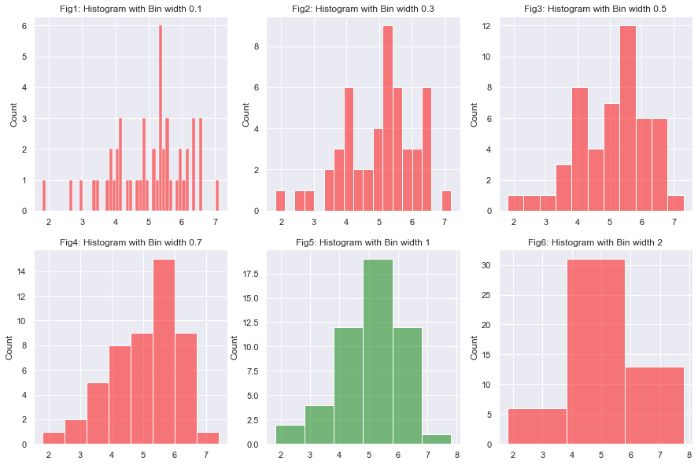

**Observations:**

- When the Bin width is small, the density estimate is too jiggly. One may assume insignificant details from the plot which may not correspond to the true density.
- On the other hand, when Bin width is large, the density estimate is too smooth. One may miss significant details from the plot which may be there in the true density.

**(b) Random sample from a $Exponential (0.2)$ distribution**

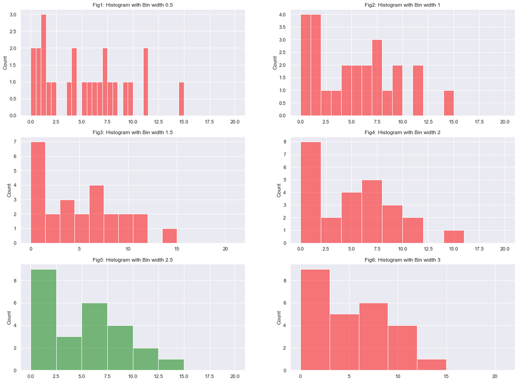

**(c) Random sample from Mixture of $Normal(0,1)$ and $Normal(4,1)$**

We have taken 40 observations from $Normal(0,1)$ and 60 observations from $Normal(4,1)$

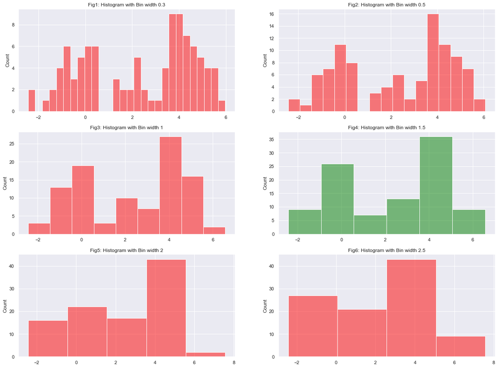

**(d) Random sample from Chisquare(4) distribution**

We have taken 50 observations Chisquare(4) distribution.

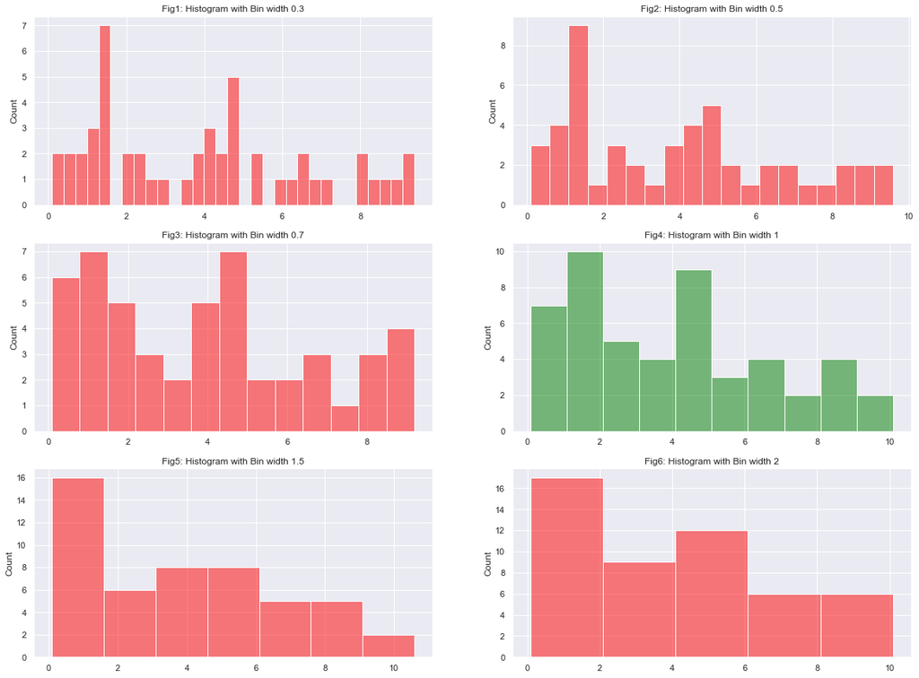

**Remarks:**

As we stated earlier, Histogram is a highly subjective structure as its shape depends on the subjective choice of the **Bin Width** which can be seen in the above Histogram plots.

There is no right or wrong answer as to how wide a bin should be, but there are rules of thumb. We need to make sure that the bins are not too small or too large. Considering the histograms we produced above: histograms use the same data but have either much smaller or larger bins.

- We can see from the histograms in where bin width is large comparatively, the density estimate will be over smoothed and one might mask some of the important characteristics, e.g. multimodality(if present) of f(x), etc.
- Histograms that have been colored as green may seem to be of optimal bandwidth in respective cases.

Further on decreasing the bin width, as shown in Histograms, the density estimate will be under smoothed and may cause the estimator to show insignificant details.

## Effect of Change in Origin in Histogram

To understand the effect of origin ,we will consider the following Histograms plotted from the same data of each distributions.

The only differene in the plots will be the value of *Bin range* that changes as we shift the origin.

**(a) Histograms from $Normal(5,1)$ distribution**

We will take a sample size of 25 observations here the binwidth is kept constant in all the plots.

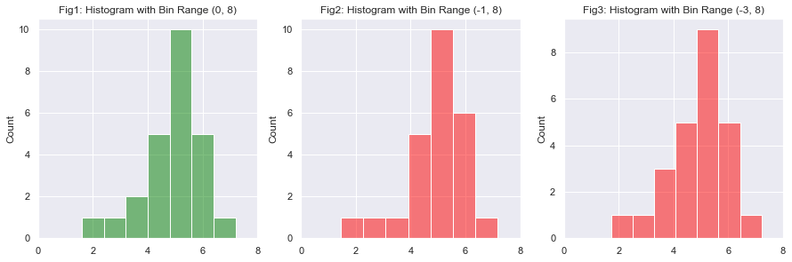

**(b) Histograms from $Exponential(0.2)$ distribution**

We will take a sample size of 25 observations here the binwidth is kept constant in all the plots.

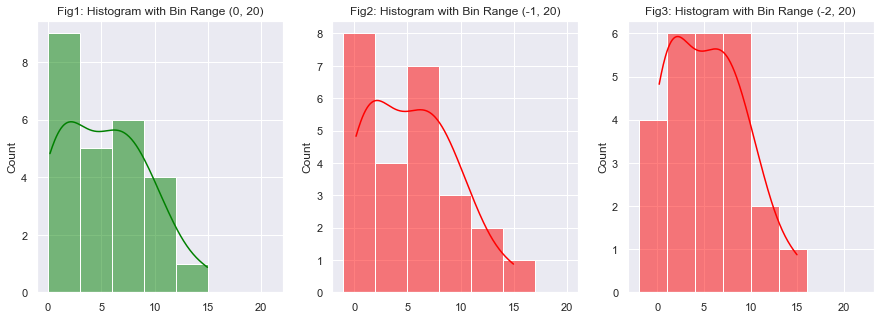

**(c) Histograms Mixture of $Normal(0,1)$ and $Normal(4,1)$**

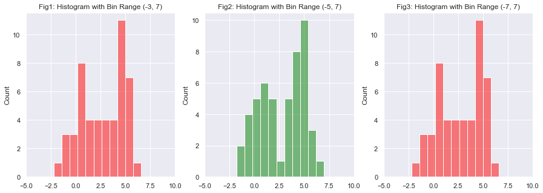

**(d) Random sample from $Chi-Square(4)$ distribution**

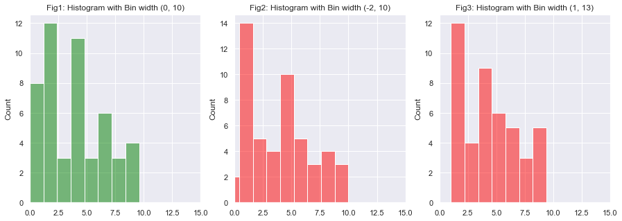

This is yet another drawback of the Histogram which makes Histogram highly subjetive .

Hence,

**For a given number of bins/bin width, moving their exact location (boundary points) can change the graph.**

## Understanding Bias and Variance in Histogram

Now we need to evaluate our estimator $\hat{f(x)}$. We can evaluate $\hat{f(x)}$ is via some measure of its difference from $f(x)$. One such measure is :

- **Mean Square Error(MSE)** : MSE is equal to the sum of variance and sqaure of Bias which are given by:

$$MSE = E(\hat{f(x)}-{f(x)})^{2}$$

$$=Var(\hat{f(x)})+Bias(\hat{f(x)})^{2}$$

where:

$$Bias^{2}(\hat{f(x)}) \approx \frac {h^{4}*(f^{(2)}(x))^{2}}{36}$$
$$Var(\hat{f(x)}) \approx \frac {f(x)}{2nh} $$

In the following graphs, the realtionship of Band width ($h$) with Bias and Variance can be seen.

We will generate two more samples from each of the distributions listed above and observe the variability and biasedness in the histogram:

**(a) Random samples from a $Normal (5,1)$ distribution**

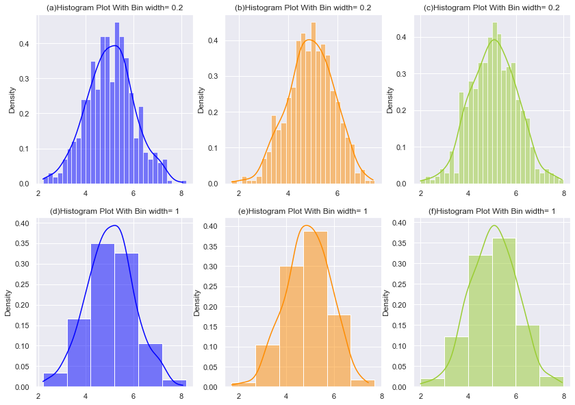

**Observations:**

Possibly every smoothing method requires a fundamental (and unavoidable) tradeoff between Bias and Variance. The above histograms illustrate this tradeoff.

1. Plot **(a), (b) and (c)** are histograms with Bin width = 0.2 each from 3 randomly generated sample from $N(5,1)$ of size 500. These plots demonstrate the difficulties with the under-smoothing. Although the bin heights follow the true density, they vary from plot to plot. This shows that **Estimator has small Bias but large Variability** which is also justified by the fact that Bias is directly proportional to bin width($h$).
1. Plots **(d), (e) and (f)** are histograms with Bin width =1 each from the same 3 samples.

These plots highlight the problem with over-smoothing. In these plots, bin heights are reasonably stable from plot to plot, but they don't follow the true density well. This shows that **Estimator has large Bias but small Variability** which is also justified by the fact that Bias is directly proportional to bin width($h$).

**(b) Random samples from a $Exponential (0.2)$ distribution**

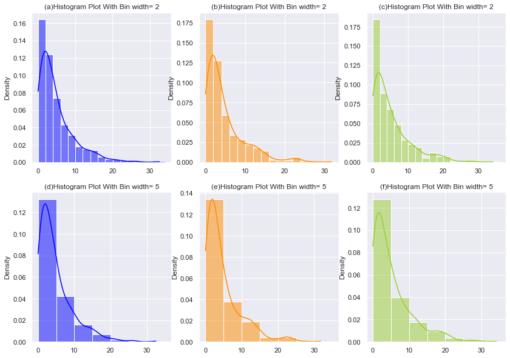

**(c) Random sample from Mixture of $Normal(0,1)$ and $Normal(4,1)$**

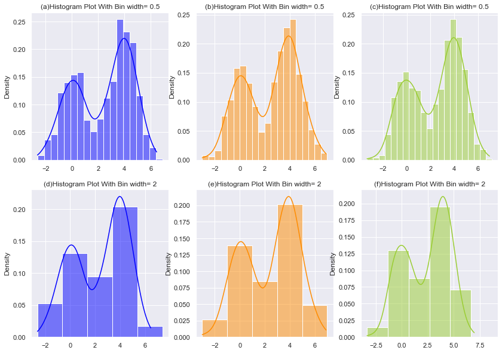

**(d) Random sample from $Chi-Square(4)$ distribution**

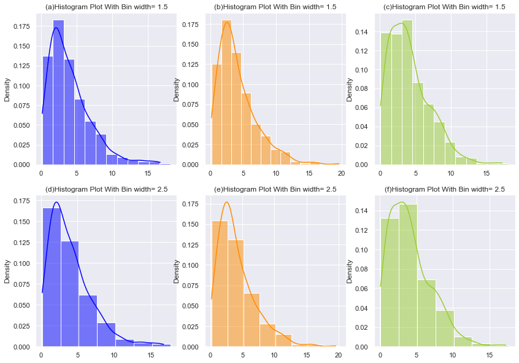

**So, from all the histograms of different distributions plotted above, we conclude that there has to be a optimal value of $h_{n}$ to have a trade- off between bias and variance.**

## Observations from Histogram Density

- To estimate the probability density at a particular location, we should consider the data points that lie within some local neighborhood of that point. Hence, this requires we define some distance measure.
- There is a natural smoothness parameter, which is the **Bin width** for the histograms.

The smoothing parameter's value should neither be too large or too small to obtain good results.

Histograms also have a few drawbacks:

1) They are not smooth

2) The depend greatly on the end points of the bins

3) They depend on the width of the bins.

These first two problems can be addressed by a histogram smoothing technique called **"Kernel density estimation"**.

# Kernel Density Estimation

Kernel density estimation (KDE) is a non-parametric method for estimating the probability density function of a given random variable. This can be useful if you want to visualize just the “shape” of some data, as a kind of continuous replacement for the discrete histogram.

Given a sample of independent, identically distributed (i.i.d) observations $X_{1},\ldots,X_{n}$ of a random variable from an unknown source distribution, the kernel density estimate, is given by:

$$ f_{n}(x) =\frac {1}{nh}\sum_{i=1}^{n}K(\frac {x-x_i}{h}) $$

where:

$f_{n}(x)$ : Kernel type estimator of $f(x)$

$h$ : Bandwidth (Smoothing Parameter)

$K(x)$ : Kernel function (Kernel is usually symmetric, a positive function that integrates to one)

**Bandwidth: $h_{n}$**

As seen in the histogram also, the bandwidth plays a key role in the quality of KDE.

- When $h_{n}$ is too small, there are many wiggly structures on our density curve. This is a signature of under smoothing–the amount of smoothing is too small so that some structure identified by our approach might be just caused by randomness.
- On the other hand, when it’s too large, our density curve may be too smoothed out. This situation is called over smoothing–some important structures are obscured by the huge amount of smoothing.

**Kernel Function: $K(x)$**

A kernel function is generally satisfies the follwing properties:

- $K(x)$ is a symmetric function
- $\int K(x)dx$ = 1
- $\displaystyle \lim_{x\to\ -∞} K(x) = \displaystyle \lim_{x\to\ ∞} K(x) = 0$

Although the choice of the kernel function does not affect the KDE much. But in practice, it often makes sense to try out a few kernels and compare the resulting KDEs. The choice of the kernel can also be influenced by some prior knowledge about the data generating process. For example, if we know a priori that the true density is continuous, we should prefer using continuous kernels.

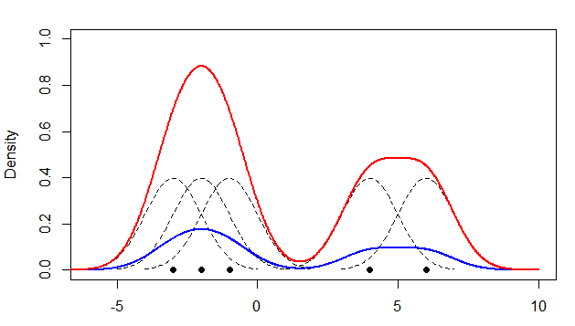

## Effect of number of Observations

The kernel density estimate at a location will be the sum of the fractions of all observations at that location. i.e For each location in the space, the kernel density is calculated by summing up the fractions of all observation points at that location. If dividing the kernel density by the total number of observation points, the result would be the probability density estimate indicating the chance that observation could occur at that location.

For simplicity, the Following figure illustrates an example of one-dimensional (univariate) kernel density estimation. from five unweighted observation points. In this example, a standard normal (Gaussian) kernel (black dashed curve) is fitted over each observation point so that the fraction of the point is the greatest at the point location and diminishes when moving away from the point. The red solid curve shows the estimate of the density function whose integral equals the total number of observation points that is five in this case, and the blue solid curve shows the estimate of the probability density function whose integral equals one.

**(a) Random sample from a $Normal(5,1)$ distribution**

For $N(5,1)$ distribution, we will fix the bandwidth $h_{n}$ and kernel as the **Gaussian kernel**.

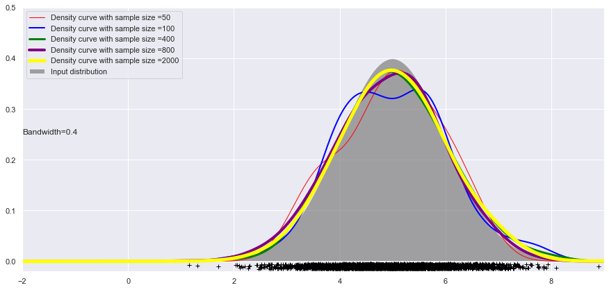

**Observation:**

From the above plot, we can clearly see that small sample density is not as accurate when compared to true density. But as we increase the sample size, the estimate gets better and tries to achieve true density.

**(b) Random samples from a $Exponential(0.2)$ distribution**

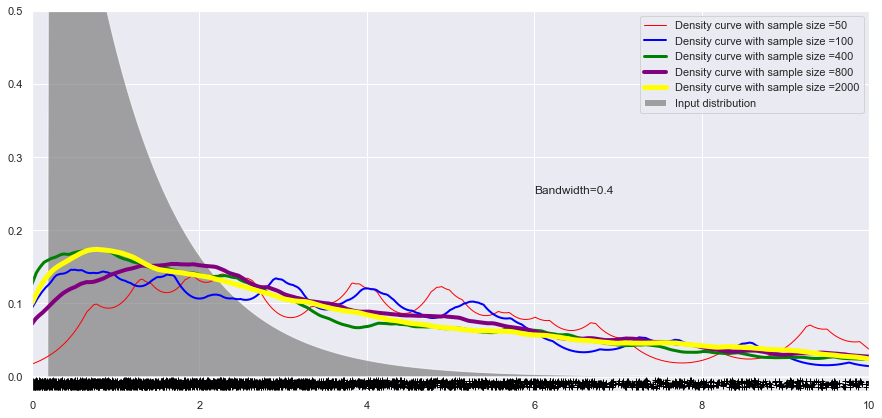

**Observation**:

Kernel Estimator does not allow for different levels of smoothing at different parts of the density, as it is controlled by single bandwidth $h$. This may not be optimal sometimes as can be seen in the above plot.

Hence, performing poorly.

**(c) Random sample from Mixture of $Normal(0,1)$ and $Normal(4,1)$**

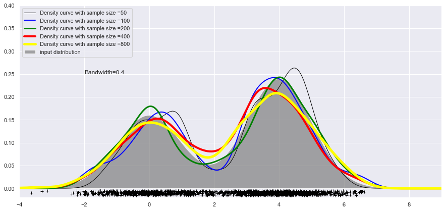

**(d) Random sample from $Chi-Square(4)$ distribution**

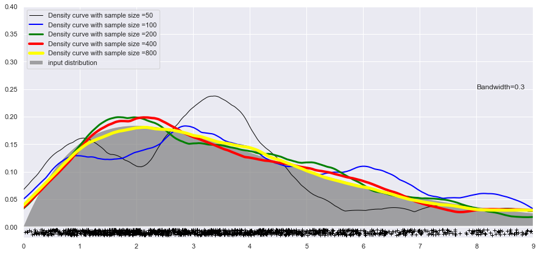

Hence,

**It is evident to say that the density estimates converge to actual pdf as $n$ increases.**

## Effect of Kernel on KDE

KDE can be used with any kernel function, and different kernels lead to density estimates with different characteristics.

Some generally used kernel functions are:

| $$Kernel$$ | $$Function$$ | $$Efficiency$$ |
| --- | --- | --- |
| Epanechnikov | $\displaystyle K(x;h)={\frac {3}{4}}(1-u)^{2})$ | 1.00 |
| Linear | $\displaystyle K(u)= (1- u)$ , | 1.01 |
| Gaussian | $K(u)={\frac {1}{\sqrt {2\pi }}}e^{-{\frac {1}{2}}u^{2}}$ | 1.0513 |
| Tophat/Unifrom | $\displaystyle K(u)={\frac {1}{2}}$ | 1.0758 |
| Exponential | $K(u)=e^{- u}$ | 2.00 |

The ratio $\frac {3}{5\sqrt5}{\sigma_{k}R(K)}$ provides a measure of the relative inefficiency of using other kernel function. The value of $\sigma_{k}R(K) $ for the Epanechnikov kernel is $\frac {3}{5\sqrt5}$.

A simple way to understand these kernel is by plotting them.

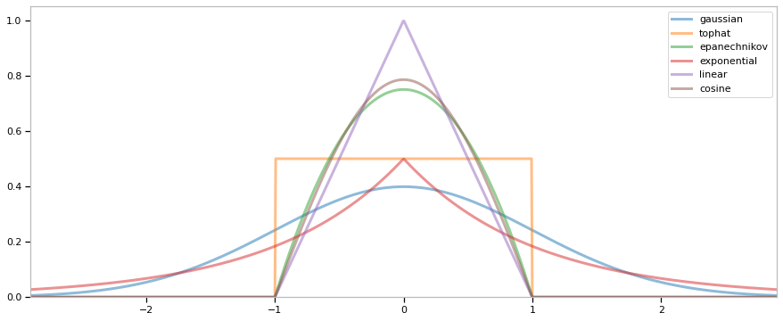

**Now lets look at he plots of KDE for various Kernels on diferent distributions.**

**(a) Random sample from mixture of logistic distribution : logistic(0,1) and logistic(2,0.5)**

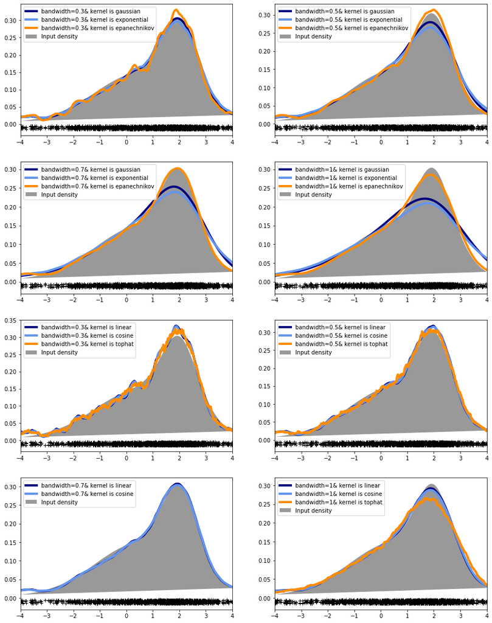

**(b) Random sample from $logNormal(0,1)$**

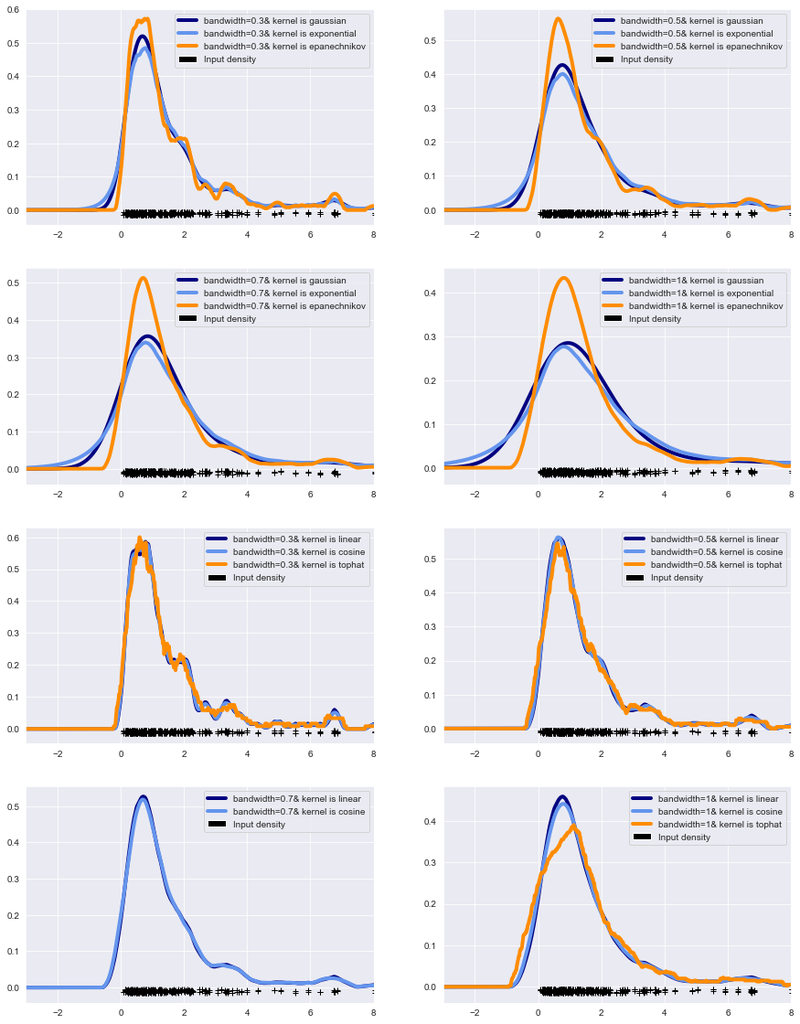

**(c) Random sample from $Chi-Square(4)$ distribution**

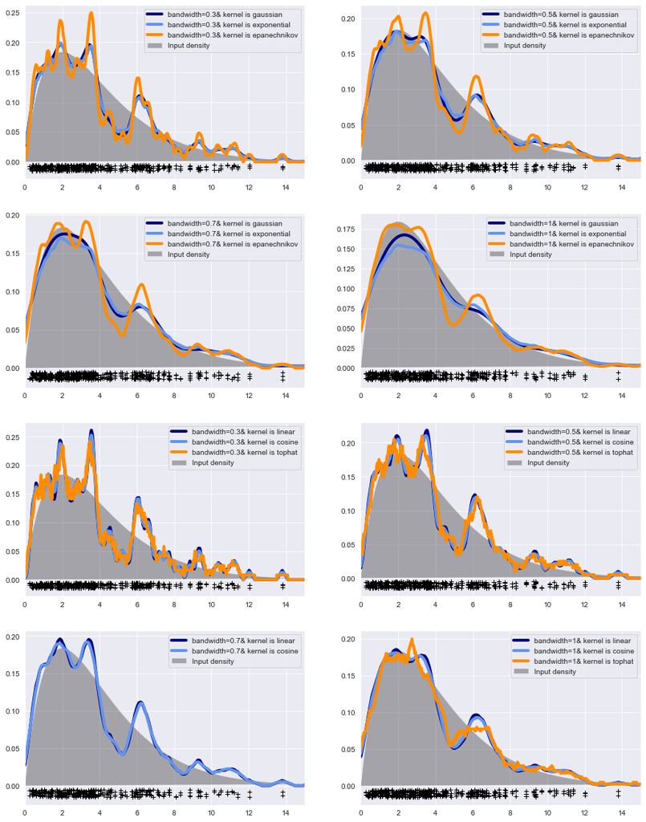

## Effect of Smoothing Parameter

KDE critically depends on the bandwidth employed i.e. the degree to which data is smoothed has a strong effect on the appearance of $\hat f(x)$ through the setting of the smoothing parameter $h$.

### Choosing an optimal value of $h$ by MISE

The first step is to define a global error criterion i.e. *The Integrated Squared Error (ISE)*,

\begin{align*} \mathrm{ISE}[\hat{f}(\cdot;h)]:=\int (\hat{f}(x;h)-f(x))^2\,\mathrm{d}x, \end{align*}

is the squared distance between the kde and the target density. The ISE is a random quantity, since it depends directly on the sample $X_{1},\ldots,X_{n}$.As a consequence, looking for an optimal-ISE bandwidth is a hard task, since the optimality is dependent on the sample itself and not only on the population and $n$.

To avoid this problem, it is usual to compute the *Mean Integrated Squared Error (MISE)*:

\begin{align*} \mathrm{MISE}[\hat{f}(\cdot;h)]:=&\,\mathbb{E}\left[\mathrm{ISE}[\hat{f}(\cdot;h)]\right]\\ =&\,\mathbb{E}\left[\int (\hat{f}(x;h)-f(x))^2\,\mathrm{d}x\right]\\ =&\,\int \mathbb{E}\left[(\hat{f}(x;h)-f(x))^2\right]\,\mathrm{d}x\\ =&\,\int \mathrm{MSE}[\hat{f}(x;h)]\,\mathrm{d}x \end{align*}$$MSE[\hat f(x)] =\frac{f(x)R(K)}{nh}+\frac{h^4\sigma^4_{k}[f^{(2)}(x)]^2}{4}+o(h^6)+ o(n^{-1})$$

When we use a *Gaussian kernel* and Standard Normal Distribution, tha value of $h_{n}$ come out to be:

\begin{align*} \hat{h}_\mathrm{n}=\left(\frac{4}{3}\right)^{1/5}n^{-1/5}\hat\sigma\approx1.06n^{-1/5}\hat\sigma. \end{align*}

For large sample size, we define AIMSE:

$$ AMISE =\frac{R(K)}{nh}+\frac{h^4\sigma^4_{K}R(f^2)}{4}$$

which will give $h$ optimal as:

$$ h_{opt}=[\frac{R(K)}{\sigma^4_{K}R(f^2)}]^{\frac{1}{5}}n^{\frac{-1}{5}}$$

where:

- $\sigma^2_{k}=\int u^2k(u)du$
- $R(f^2)$ measures the roughness of the true underlying density (out of the control of the data analyst)

.

### Choosing an optimal value of $h$ by Least Square Cross-Validation

he idea is to use the sample twice: one for computing the KDE and other for evaluating its performance on estimating $f$ . To avoid the clear dependence on the sample, we do this evaluation in a cross-validatory way: the data used for computing the KDE is not used for its evaluation.

We begin by expanding the square in the MISE expression:

\begin{align*} \mathrm{MISE}[\hat{f}(\cdot;h)]=&\,\mathbb{E}\left[\int (\hat{f}(x;h)-f(x))^2\,\mathrm{d}x\right]\\ =&\,\mathbb{E}\left[\int \hat{f}(x;h)^2\,\mathrm{d}x\right]-2\mathbb{E}\left[\int \hat{f}(x;h)f(x)\,\mathrm{d}x\right]+\int f(x)^2\,\mathrm{d}x.\\ \end{align*}

Since the last term does not depend on $h$, minimizing $\mathrm{MISE}[\hat{f}(\cdot;h)]$ is equivalent to minimizing:

\begin{align} \\R(\hat{f}):= \mathbb{E}\left[\int \hat{f}(x;h)^2\,\mathrm{d}x\right]-2\mathbb{E}\left[\int \hat{f}(x;h)f(x)\,\mathrm{d}x\right].\tag{2.28} \end{align}

This quantity is unknown, but it can be estimated unbiasedly by:

\begin{align} \mathrm{LSCV}(h):=\int\hat{f}(x;h)^2\,\mathrm{d}x-2n^{-1}\sum_{i=1}^n\hat{f}_{-i}(X_i;h) \end{align}

where $\hat{f}_{-i}(\cdot;h)$ is the *leave-one-out* KDE and is based on the sample with the $X_{i}$ removed:

\begin{align*} \hat{f}_{-i}(x;h)=\frac{1}{n-1}\sum_{\substack{j=1\\j\neq i}}^n K_h(x-X_j). \end{align*}

Further we can prove that, \begin{align*} \mathbb{E}[\mathrm{LSCV}(h)] = \mathbb{E}[R(\hat{f})] \end{align*}

In order to mitigate the dependence of the sample, we replace $\hat{f}(X_i;h)$ with $\hat{f}_{-i}(X_i;h)$.In that way, we use the sample for estimating the integral involving $\hat{f}(\cdot;h)$ but for each $X_{i}$ we compute the KDE on the remaining points.

The Least Squares Cross-Validation (LSCV) selector is defined as:

\begin{align*} \hat{h}_\mathrm{LSCV}:=\arg\min_{h>0}\mathrm{LSCV}(h). \end{align*}

which can be be calculated by softwares with standard functions.

**(a) Random sample from a $Normal (5,1)$ distribution**

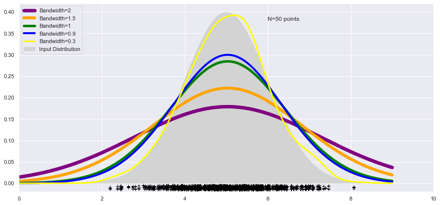

**Observation:**

- Optimal bandwidth calculated from Cross Validation is:

```
Optimal bandwidth from Least Square Cross-Validation is: {'bandwidth': 0.342685370741483}
```

This can also be verified from the KDE plotted above.

**(b) Random sample from Mixture of $Normal(0,1)$ and $Normal(4,1)$**

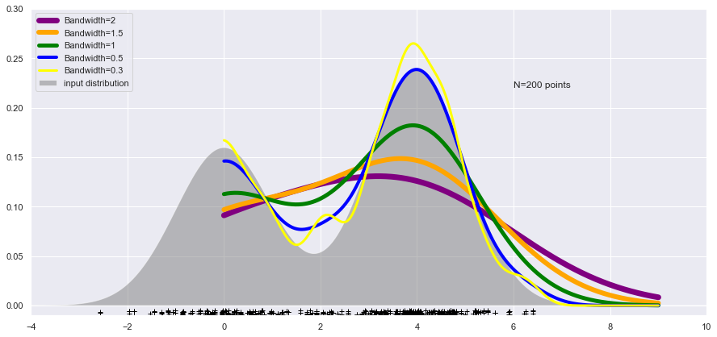

**Observations:**

- Optimal bandwidth calculated from Cross Validation is:

```
Optimal bandwidth from Least Square Cross-Validation is: {'bandwidth': 0.5006257822277851}
```

**(c) Random sample from $Chi-Square(4)$ distribution**

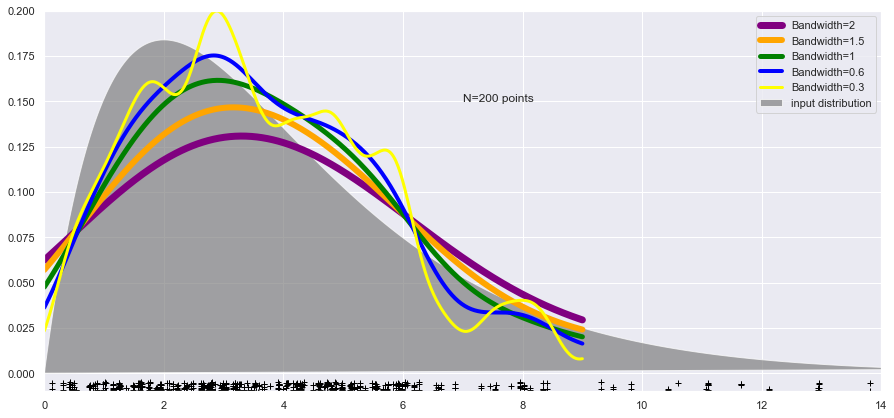

**Observations:**

- Optimal bandwidth calculated from Cross Validation is:

```
Optimal bandwidth from Least Square Cross-Validation is: {'bandwidth': 0.594493116395495}
```

# Conclusion

**Kernel Density Estimation**

- KDE is a more refined method with more efficient results in estimating the density of the given sample.
- Choice of the kernel does not have a significant effect on the density estimate.
- With the increase in the number of observations, KDE tends to converge to the true density.
- Bandwidth/smoothing parameter plays an important role in kernel density estimation. Similar to that in a histogram, problems like over smoothing and under smoothing may arise if the optimal value of $h$ is not taken.
- Optimal $h$ will result in a trade-off between bias and variance for which techniques like cross-validation can be used.